# Replikacja efektu epistemicznego w języku polskim - raport z badania

## Autorzy badania: Sławomir Mijas, Ignacy Szczeniowski, Marta Zaręba, Katarzyna Kuś, Bartosz Maćkiewicz

## Cel badania:

Replikacja efektu epistemicznego na polskich czasownikach epistemicznych.

## Konstrukcja badania:

Badanie było replikacją badania, pokazującego istnienie efektu epistemicznego w języku angielskim.

Efekt epistemiczny polega na tym, że badani konfrontowani z oryginalnymi scenariuszami z eksperymentu Knobe’a odpowiadają na pytanie “Did the chairman know that the environment will be harmed/helped” w sposób asymetryczny.

Jako odpowiedniki angielskiego “know” wybraliśmy dwa czasowniki polskie epistemiczne: - Wiedzieć - Sądzić

W oryginalnym badaniu użyta została strona bierna (“environment will be harmed/helped”). W języku polskim nie można utworzyć strony biernej od czasowników “szkodzić” i “pomagać”. Wybraliśmy zatem trzy najbliższe oryginalnemu sformułowaniu wersje: - “…zaszkodzi/pomoże środowisku” (forma agentywna) - “…program zaszkodzi/pomoże środowisku” (forma kauzalna) - “…stan środowiska się pogorszy/polepszy” (pytanie o stan środowiska)

Każdemu z badanych zaprezentowana był jeden z dwóch scenariuszy, w których w miejscu oznaczonym [e-formuła] stał odpowiedni czasownik epistemiczny wraz z dopełnieniem:

**Scenariusz HARM**

Wicedyrektor zwraca się do dyrektora pewnej firmy:

„Myślimy o wdrożeniu nowego programu. Pozwoli nam zwiększyć zyski, ale zaszkodzi środowisku”.

Dyrektor odpowiada:

„Nie obchodzi mnie szkodzenie środowisku. Chcę tylko zwiększyć zyski. Wdrażamy program”.

Program został wdrożony i rzeczywiście zaszkodził środowisku.

Czy dyrektor [e-formuła]?

**Scenariusz HELP**

Wicedyrektor zwraca się do dyrektora pewnej firmy:

„Myślimy o wdrożeniu nowego programu. Pozwoli nam zwiększyć zyski i pomoże środowisku”.

Dyrektor odpowiada:

„Nie obchodzi mnie pomaganie środowisku. Chcę tylko zwiększyć zyski. Wdrażamy program”.

Program został wdrożony i rzeczywiście pomógł środowisku.

Czy dyrektor [e-formuła] pomógł środowisku?

## Technikalia

Każdemu z badanych zaprezentowany był tylko jeden scenariusz. Czas na odpowiedź był nieograniczony. Badanie odbyło się za pośrednictwem internetowego systemu ankietowego Limesurvey na platformie uniwersyteckiej Kognilab.

## Wyniki:

### Wiedział + forma agentywna (“…zaszkodzi/pomoże środowisku”):

```
##         GROUP
## RESPONSE Harm Help
##      0      0    0
##      Nie    1    6
##      Tak   82   73
```

#### Test istotności statystycznej:

```
##
##  Pearson's Chi-squared test with Yates' continuity correction
##
## data:  GROUP and RESPONSE
## X-squared = 2.6014, df = 1, p-value = 0.1068
```

#### Wykres:

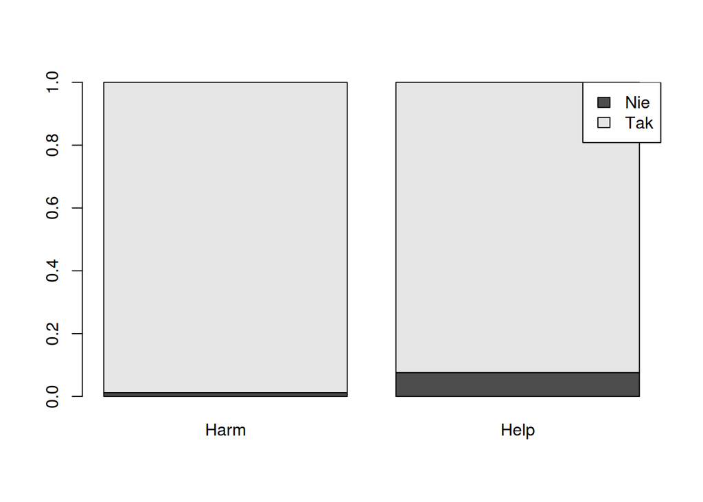

### Wiedział + forma kauzalna (“…program zaszkodzi/pomoże środowisku”)

```
##         GROUP
## RESPONSE Harm Help
##      0      0    0
##      Nie    2   18
##      Tak   41   54
```

#### Test istotności statystycznej:

```
##
##  Pearson's Chi-squared test with Yates' continuity correction
##
## data:  GROUP and RESPONSE
## X-squared = 6.4076, df = 1, p-value = 0.01136
```

#### Wykres:

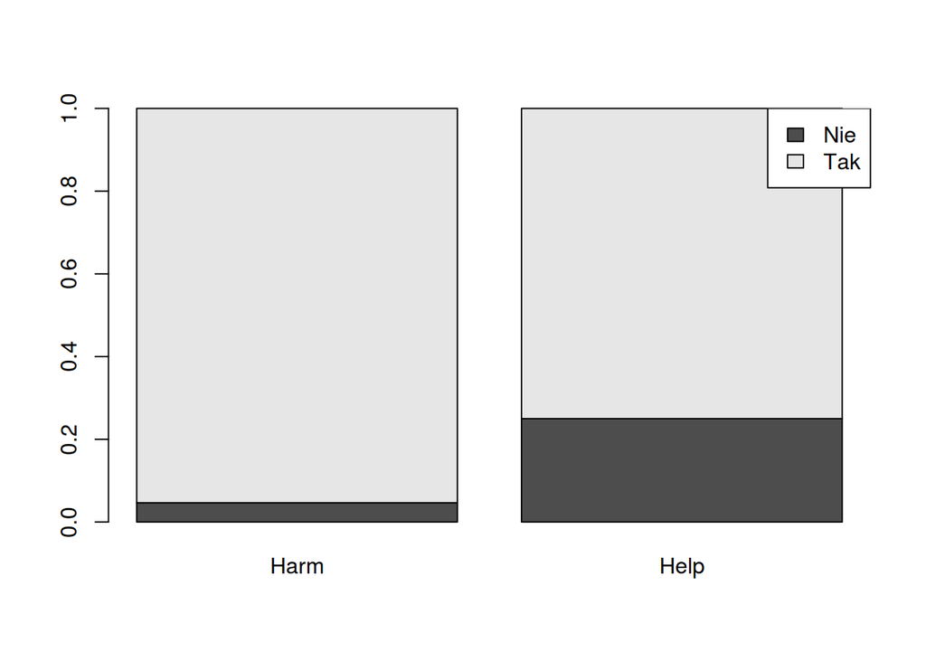

### Wiedział + pytanie o stan środowiska (“…stan środowiska się pogorszy/polepszy”)

```
##         GROUP
## RESPONSE Harm Help
##      0      0    0
##      Nie    3   19
##      Tak   52   44
```

#### Test istotności statystycznej:

```
##
##  Pearson's Chi-squared test with Yates' continuity correction
##
## data:  GROUP and RESPONSE
## X-squared = 10.242, df = 1, p-value = 0.001372
```

#### Wykres:

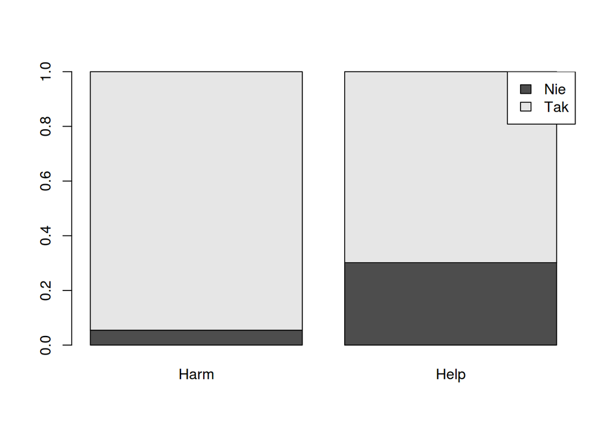

### Sądził + forma agentywna (“…zaszkodzi/pomoże środowisku”):

```
##         GROUP
## RESPONSE Harm Help
##      0      0    0
##      Nie   13   42
##      Tak   38   22
```

#### Test istotności statystycznej:

```
##
##  Pearson's Chi-squared test with Yates' continuity correction
##
## data:  GROUP and RESPONSE
## X-squared = 16.749, df = 1, p-value = 4.266e-05
```

#### Wykres:

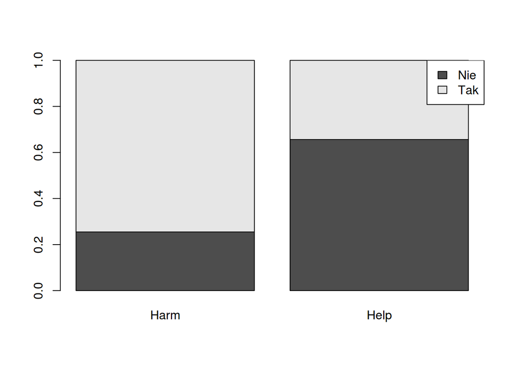

### Sądził + forma kauzalna (“…program zaszkodzi/pomoże środowisku”)

```
##         GROUP
## RESPONSE Harm Help
##      0      0    0
##      Nie   33   13
##      Tak   32   52
```

#### Test istotności statystycznej:

```
##
##  Pearson's Chi-squared test with Yates' continuity correction
##
## data:  GROUP and RESPONSE
## X-squared = 12.145, df = 1, p-value = 0.0004921
```

#### Wykres:

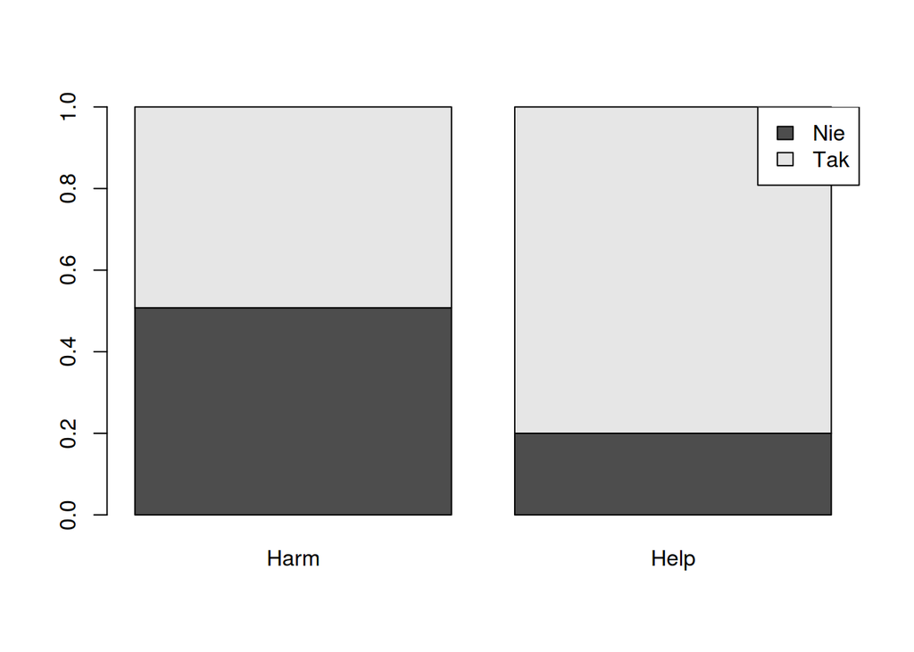

### Sądził + pytanie o stan środowiska (“…stan środowiska się pogorszy/polepszy”)

```
##         GROUP
## RESPONSE Harm Help
##      0      0    0
##      Nie   29   19
##      Tak   38   49
```

#### Test istotności statystycznej:

```
##
##  Pearson's Chi-squared test with Yates' continuity correction
##
## data:  GROUP and RESPONSE
## X-squared = 2.8297, df = 1, p-value = 0.09254
```

#### Wykres:

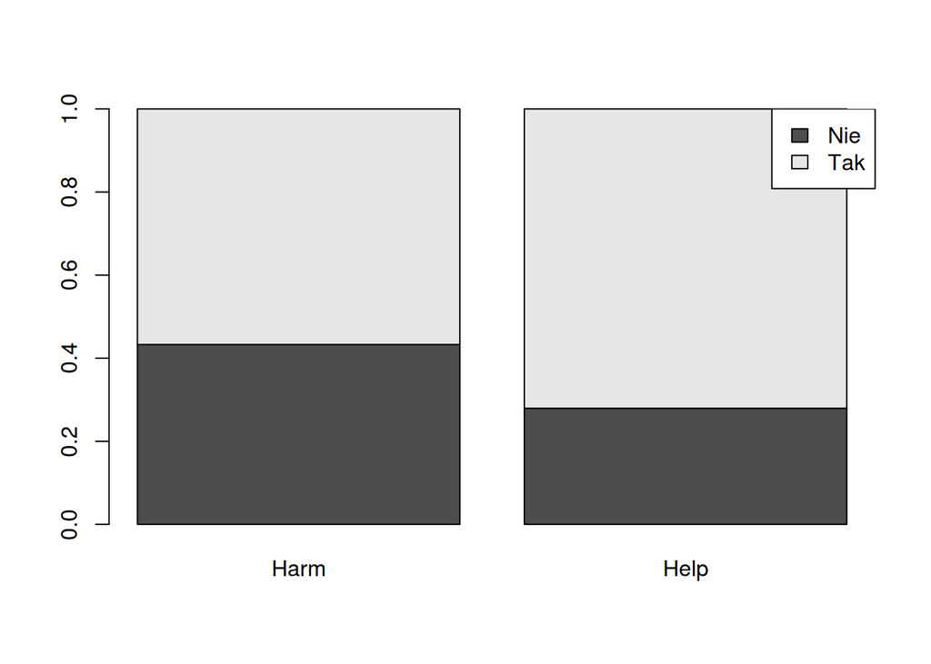